# Dataset: ‘dataset_1’ LASSO summary

## Full model prediction accuracy

| drug | 1 | 0 | 1/1 | 1/0 | 0/1 | 0/0 | precission | recall | f1 | accuracy |
| --- | --- | --- | --- | --- | --- | --- | --- | --- | --- | --- |
| EMB | 102 | 30 | 0.7727 | 0.0000 | 0.0076 | 0.2197 | 0.9903 | 1.0000 | 0.9951 | 0.9924 |
| INH | 106 | 26 | 0.8030 | 0.0000 | 0.0000 | 0.1970 | 1.0000 | 1.0000 | 1.0000 | 1.0000 |
| RIF | 106 | 26 | 0.8030 | 0.0000 | 0.0000 | 0.1970 | 1.0000 | 1.0000 | 1.0000 | 1.0000 |
| PZA | 28 | 6 | 0.8235 | 0.0000 | 0.0000 | 0.1765 | 1.0000 | 1.0000 | 1.0000 | 1.0000 |
| STM | 110 | 22 | 0.8333 | 0.0000 | 0.0076 | 0.1591 | 0.9910 | 1.0000 | 0.9955 | 0.9924 |
| OFLO | 69 | 63 | 0.4848 | 0.0379 | 0.0455 | 0.4318 | 0.9143 | 0.9275 | 0.9209 | 0.9167 |

## Reduced model prediction accuracy

| drug | 1 | 0 | 1/1 | 1/0 | 0/1 | 0/0 | precission | recall | f1 | accuracy |
| --- | --- | --- | --- | --- | --- | --- | --- | --- | --- | --- |
| EMB | 102 | 30 | 0.7727 | 0.0000 | 0.0000 | 0.2273 | 1.0000 | 1.000 | 1.000 | 1.0000 |
| INH | 106 | 26 | 0.8030 | 0.0000 | 0.0000 | 0.1970 | 1.0000 | 1.000 | 1.000 | 1.0000 |
| RIF | 106 | 26 | 0.8030 | 0.0000 | 0.0000 | 0.1970 | 1.0000 | 1.000 | 1.000 | 1.0000 |
| PZA | 28 | 6 | 0.8235 | 0.0000 | 0.0000 | 0.1765 | 1.0000 | 1.000 | 1.000 | 1.0000 |
| STM | 110 | 22 | 0.8333 | 0.0000 | 0.0000 | 0.1667 | 1.0000 | 1.000 | 1.000 | 1.0000 |
| OFLO | 69 | 63 | 0.5076 | 0.0152 | 0.0227 | 0.4545 | 0.9571 | 0.971 | 0.964 | 0.9621 |

## ‘EMB’ Details

### Elastic Net for Best Lambda

Lambda that minimizes CV error

```
## [1] 0.02
```

Corresponding CV error

```
## [1] 0.4341
```

Number of nonzero coefficients (all non-zero)

```
## s49
##  41
```

Nonzero coefficients*:

| position | bp | coeficient |
| --- | --- | --- |
| 6 | 1977 | 0.0566 |
| 11 | 7572 | 0.4741 |
| 13 | 7582 | -0.4790 |
| 24 | 25899 | 1.3525 |
| 31 | 35978 | -0.1899 |
| 36 | 42227 | 0.9932 |
| 66 | 104835 | 0.1441 |
| 85 | 152423 | 0.1104 |
| 112 | 336053 | -0.3098 |
| 170 | 475181 | -0.1328 |
| 182 | 673241 | 1.7403 |
| 186 | 761158 | 1.2223 |
| 190 | 781825 | -0.2601 |
| 198 | 839980 | -0.0600 |
| 244 | 1096571 | 1.4232 |
| 248 | 1164813 | 0.3358 |
| 251 | 1169452 | 0.1289 |
| 280 | 1276890 | -0.0629 |
| 281 | 1276943 | 0.0913 |
| 307 | 1473252 | -0.7290 |
| 331 | 1619122 | 1.5150 |
| 356 | 1637203 | 0.3299 |
| 357 | 1637210 | -0.1916 |
| 366 | 1673431 | -1.0062 |
| 371 | 1779376 | 1.1151 |
| 440 | 2165510 | 0.2221 |
| 447 | 2196722 | 0.4949 |
| 485 | 2339613 | 1.3249 |
| 503 | 2626404 | 0.3819 |
| 505 | 2626610 | 2.0083 |
| 507 | 2633638 | 0.0176 |
| 565 | 3246903 | 3.4561 |
| 605 | 3732260 | 0.4321 |
| 618 | 3735984 | -0.1218 |
| 641 | 3842469 | -1.8907 |
| 660 | 3884039 | 0.6926 |
| 700 | 3936511 | 0.3689 |
| 705 | 3942660 | 0.3683 |
| 710 | 3943332 | 1.6926 |
| 726 | 3948891 | 0.0184 |
| 750 | 4248181 | -0.6393 |

### Charts

Nonzero coefficients (LASSO):

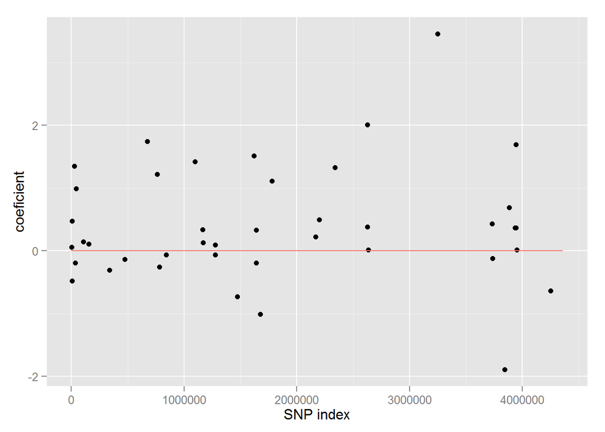

ROC curve for full model

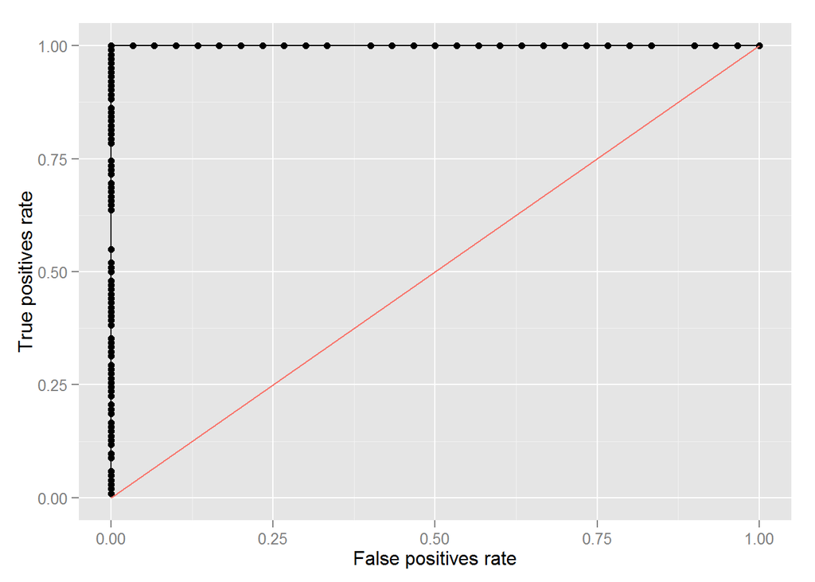

ROC curve for reduced model

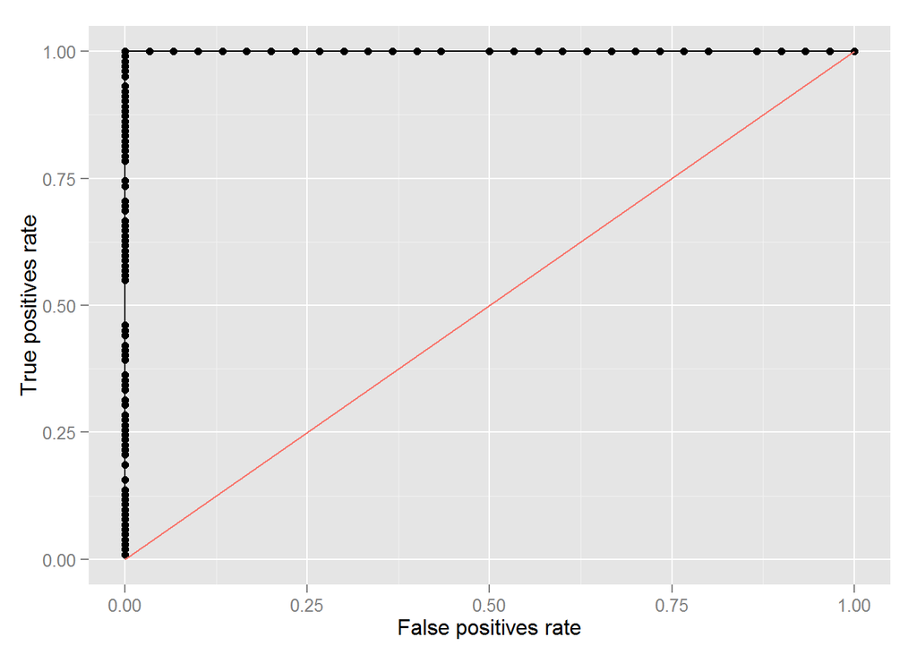

## ‘INH’ Details

### Elastic Net for Best Lambda

Lambda that minimizes CV error

```
## [1] 0.02
```

Corresponding CV error

```
## [1] 0.3226
```

Number of nonzero coefficients (all non-zero)

```
## s49
##  34
```

Nonzero coefficients*:

| position | bp | coeficient |
| --- | --- | --- |
| 1 | 698 | -0.1113 |
| 6 | 1977 | 0.8752 |
| 24 | 25899 | 1.5197 |
| 26 | 28640 | 0.2848 |
| 66 | 104835 | 0.2105 |
| 81 | 119102 | 1.7819 |
| 85 | 152423 | 1.3879 |
| 107 | 333682 | -0.0776 |
| 182 | 673241 | 0.0655 |
| 186 | 761158 | 2.2593 |
| 237 | 1096006 | -0.3245 |
| 244 | 1096571 | 1.6107 |
| 248 | 1164813 | 0.6525 |
| 281 | 1276943 | 0.3476 |
| 303 | 1461315 | 0.0379 |
| 307 | 1473252 | -0.1290 |
| 370 | 1779376 | 1.4285 |
| 410 | 1998844 | 0.4003 |
| 446 | 2196722 | 0.4838 |
| 484 | 2339613 | 1.2751 |
| 487 | 2348454 | 0.0584 |
| 502 | 2626404 | 0.5935 |
| 504 | 2626610 | 1.9381 |
| 564 | 3246903 | 1.7906 |
| 604 | 3732260 | 0.1566 |
| 617 | 3735984 | -0.0286 |
| 635 | 3798275 | 0.0539 |
| 640 | 3842469 | -2.1476 |
| 656 | 3883975 | 0.0292 |
| 659 | 3884039 | 1.0307 |
| 689 | 3934878 | 0.1061 |
| 704 | 3942660 | 0.6947 |
| 714 | 3946429 | 1.3886 |
| 749 | 4248181 | -0.7484 |

### Charts

Nonzero coefficients (LASSO):

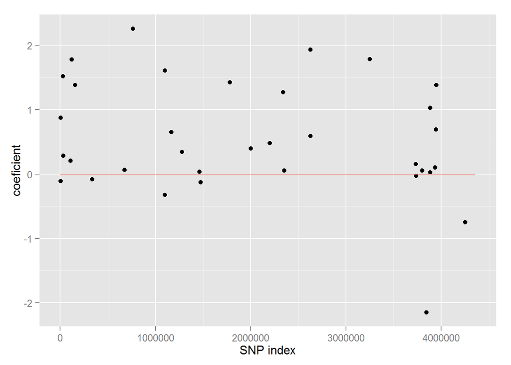

ROC curve for full model

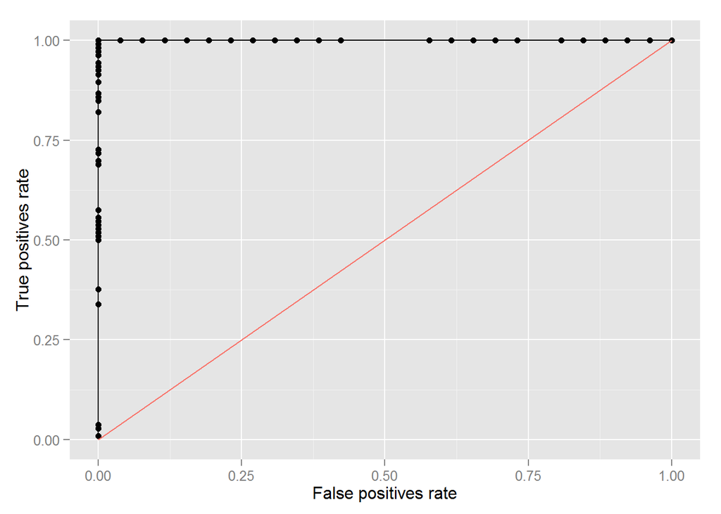

ROC curve for reduced model

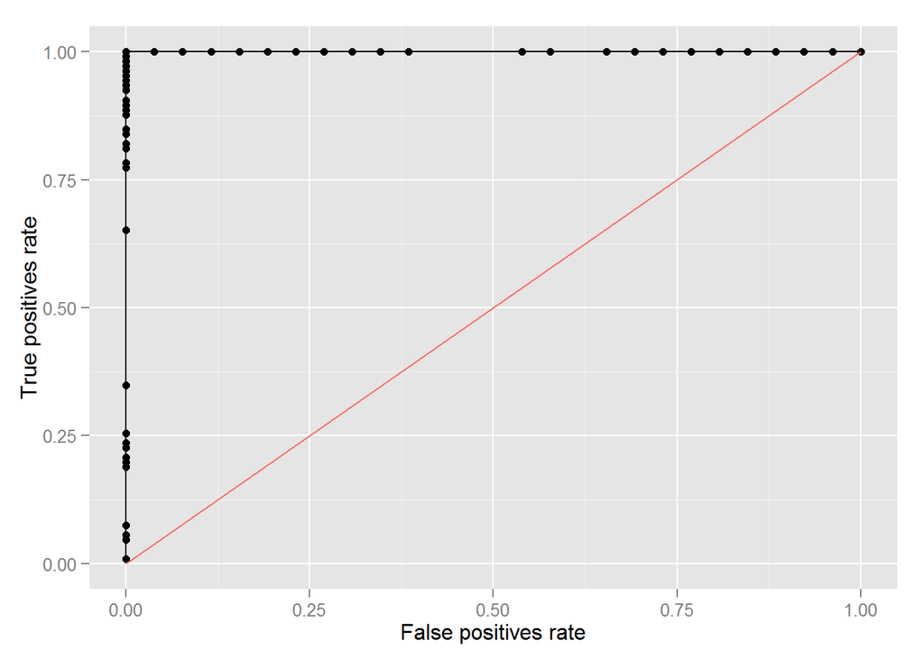

## ‘RIF’ Details

### Elastic Net for Best Lambda

Lambda that minimizes CV error

```
## [1] 0.04
```

Corresponding CV error

```
## [1] 0.4373
```

Number of nonzero coefficients (all non-zero)

```
## s48
##  29
```

Nonzero coefficients*:

| position | bp | coeficient |
| --- | --- | --- |
| 6 | 1977 | 0.9064 |
| 24 | 25899 | 1.4468 |
| 26 | 28640 | 0.1052 |
| 66 | 104835 | 0.2636 |
| 81 | 119102 | 1.9249 |
| 85 | 152423 | 1.1009 |
| 182 | 673241 | 0.0240 |
| 188 | 781690 | -0.4191 |
| 199 | 854607 | -0.0808 |
| 243 | 1096571 | 1.5536 |
| 244 | 1161030 | -0.0276 |
| 247 | 1164813 | 0.3461 |
| 280 | 1276943 | 0.0537 |
| 306 | 1473252 | -0.3019 |
| 359 | 1638194 | 0.0818 |
| 365 | 1673431 | -0.3387 |
| 370 | 1779376 | 0.8814 |
| 446 | 2196722 | 0.2416 |
| 484 | 2339613 | 1.3164 |
| 487 | 2348454 | 0.0198 |
| 502 | 2626404 | 0.3227 |
| 504 | 2626610 | 2.1306 |
| 519 | 2829304 | 0.4099 |
| 564 | 3246903 | 1.8139 |
| 640 | 3842469 | -1.1434 |
| 656 | 3883975 | 0.3839 |
| 659 | 3884039 | 0.7492 |
| 704 | 3942660 | 0.8567 |
| 714 | 3946429 | 1.4735 |

### Charts

Nonzero coefficients (LASSO):

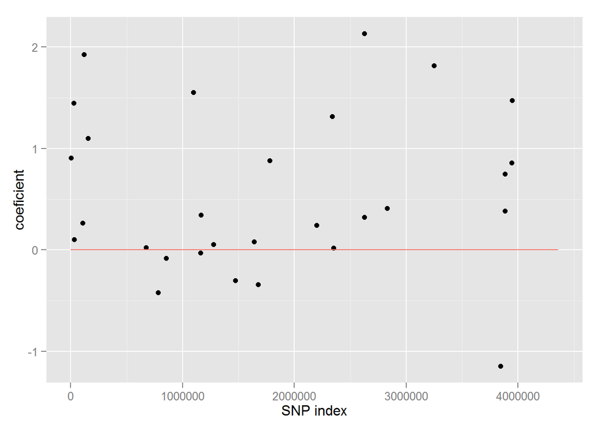

ROC curve for full model

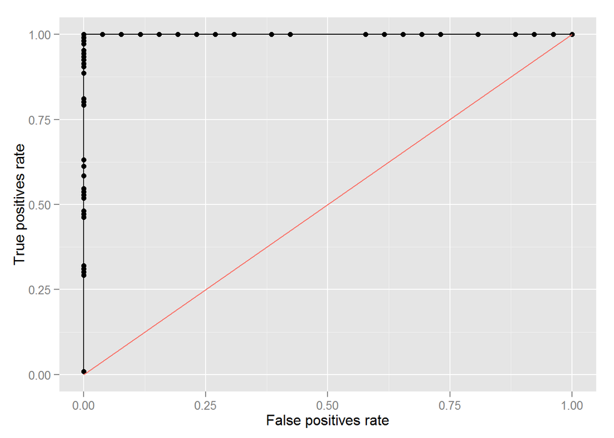

ROC curve for reduced model

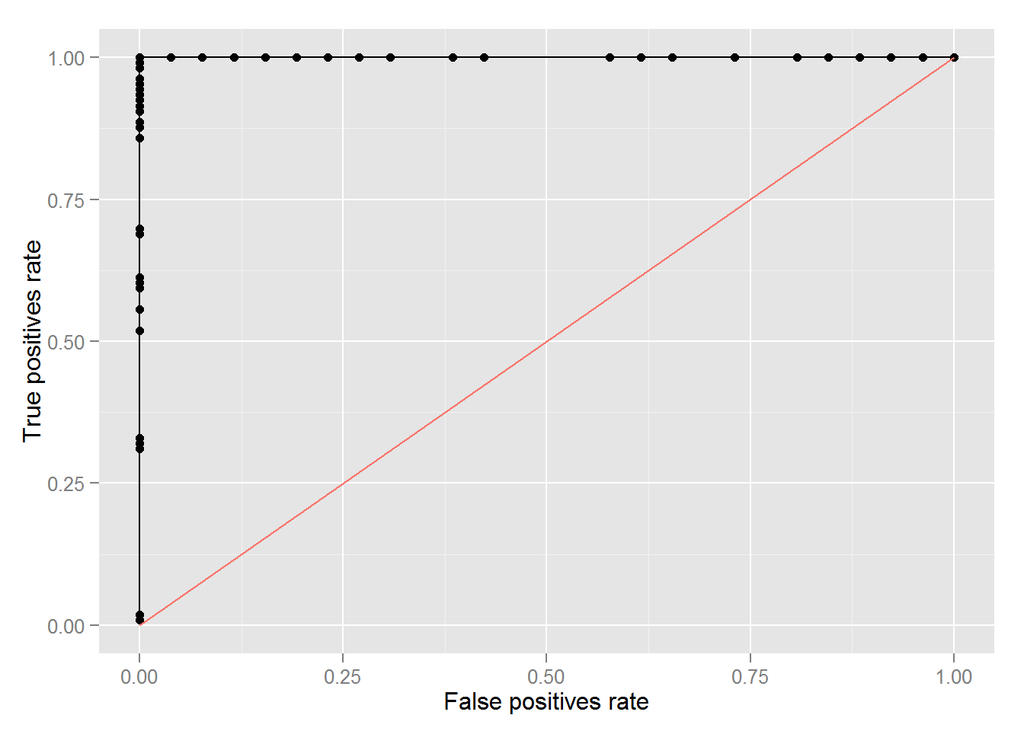

## ‘PZA’ Details

### Elastic Net for Best Lambda

Lambda that minimizes CV error

```
## [1] 0.1
```

Corresponding CV error

```
## [1] 0.6845
```

Number of nonzero coefficients (all non-zero)

```
## s45
##  19
```

Nonzero coefficients*:

| position | bp | coeficient |
| --- | --- | --- |
| 24 | 25899 | 0.1446 |
| 71 | 104941 | 0.2301 |
| 108 | 335845 | 0.1347 |
| 243 | 1096512 | 0.5007 |
| 244 | 1096571 | 0.4992 |
| 296 | 1385345 | 2.5753 |
| 430 | 2155175 | 1.0540 |
| 442 | 2165855 | 0.1373 |
| 453 | 2196976 | 0.4441 |
| 504 | 2626404 | 0.1787 |
| 506 | 2626610 | 0.1785 |
| 508 | 2633638 | 0.1510 |
| 658 | 3883975 | 0.4931 |
| 659 | 3883976 | 0.4907 |
| 706 | 3942660 | 0.4910 |
| 718 | 3947016 | 0.1628 |
| 719 | 3947022 | 0.1687 |
| 720 | 3947037 | 0.1658 |
| 727 | 3948891 | 0.1558 |

### Charts

Nonzero coefficients (LASSO):

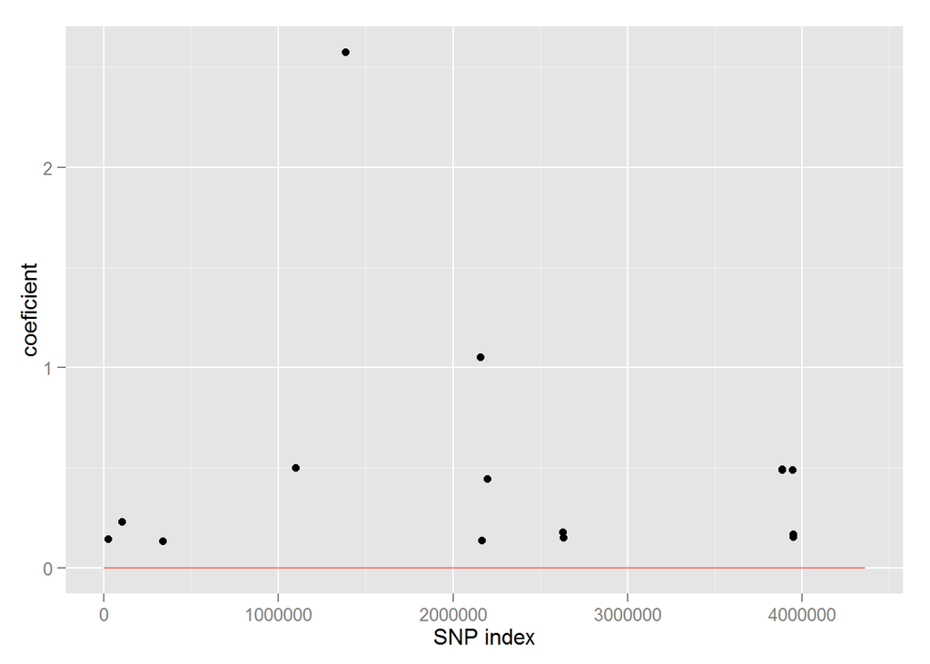

ROC curve for full model

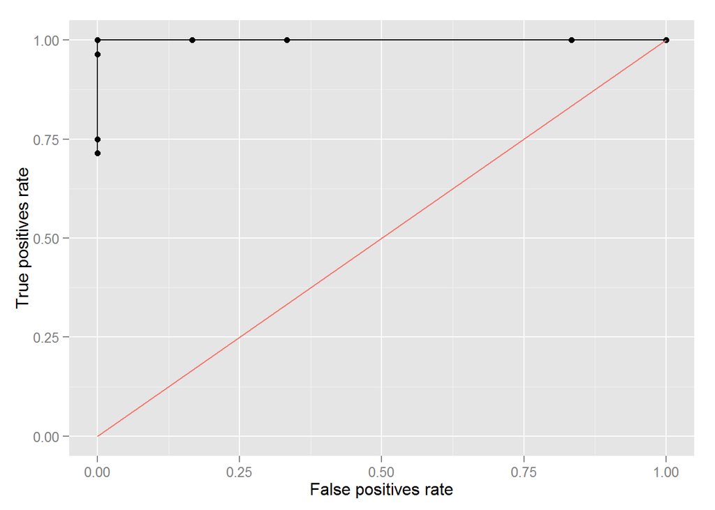

ROC curve for reduced model

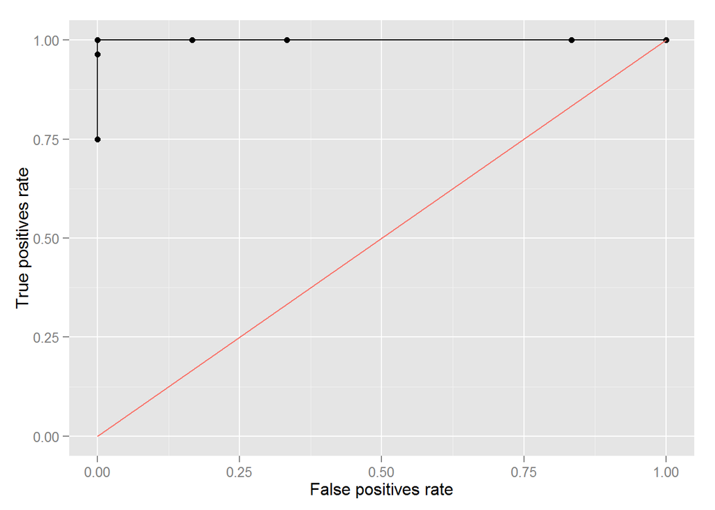

## ‘STM’ Details

### Elastic Net for Best Lambda

Lambda that minimizes CV error

```
## [1] 0.04
```

Corresponding CV error

```
## [1] 0.4457
```

Number of nonzero coefficients (all non-zero)

```
## s48
##  35
```

Nonzero coefficients*:

| position | bp | coeficient |
| --- | --- | --- |
| 6 | 1977 | 0.8927 |
| 24 | 25899 | 0.9041 |
| 29 | 34879 | 0.1792 |
| 45 | 70023 | 0.4394 |
| 50 | 75937 | -0.0252 |
| 81 | 119102 | 0.6171 |
| 85 | 152423 | 0.4281 |
| 130 | 338416 | 0.1595 |
| 136 | 338768 | 0.3645 |
| 182 | 673241 | 0.1107 |
| 186 | 761158 | 0.9715 |
| 243 | 1096512 | 0.0225 |
| 244 | 1096571 | 0.0072 |
| 248 | 1164813 | 0.9307 |
| 252 | 1169970 | 0.0361 |
| 309 | 1480978 | -0.0102 |
| 313 | 1490810 | 0.6500 |
| 348 | 1636942 | -0.1090 |
| 349 | 1636950 | -0.1119 |
| 351 | 1636952 | -0.3120 |
| 366 | 1673431 | -0.3380 |
| 371 | 1779376 | 0.8073 |
| 414 | 2045317 | 0.1267 |
| 430 | 2155175 | 1.5289 |
| 448 | 2196722 | 0.1591 |
| 452 | 2196971 | 0.0949 |
| 504 | 2626404 | 1.2827 |
| 506 | 2626610 | 0.6746 |
| 566 | 3246903 | 1.8424 |
| 621 | 3736102 | 0.4958 |
| 637 | 3798275 | 0.1134 |
| 643 | 3842662 | 1.4536 |
| 664 | 3885085 | -0.0596 |
| 716 | 3946429 | 0.4279 |
| 738 | 4121290 | 0.0125 |

### Charts

Nonzero coefficients (LASSO):

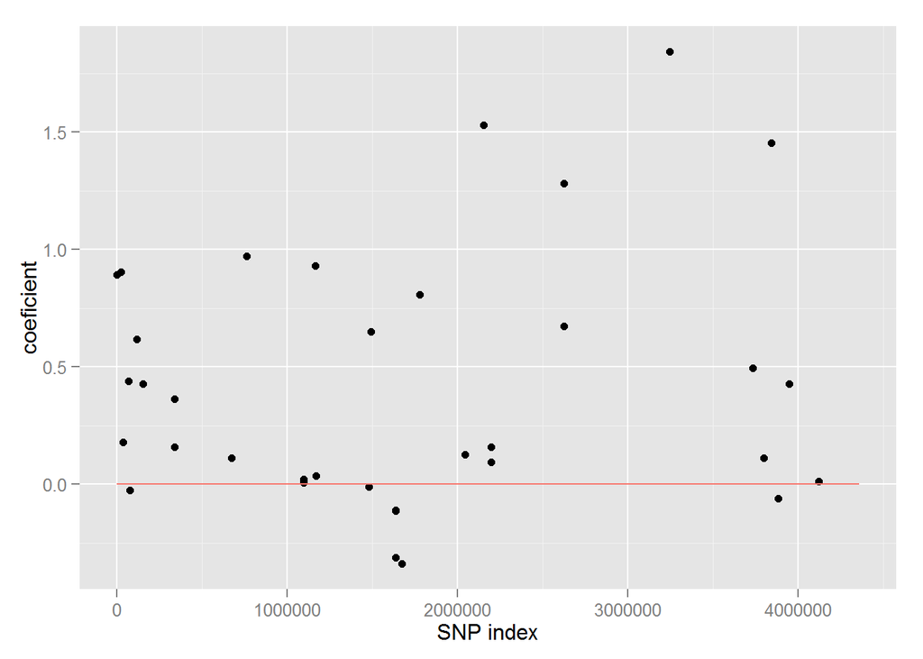

ROC curve for full model

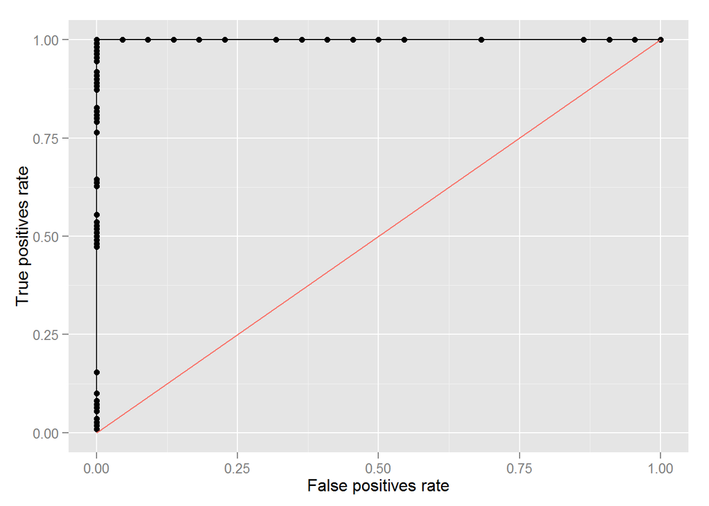

ROC curve for reduced model

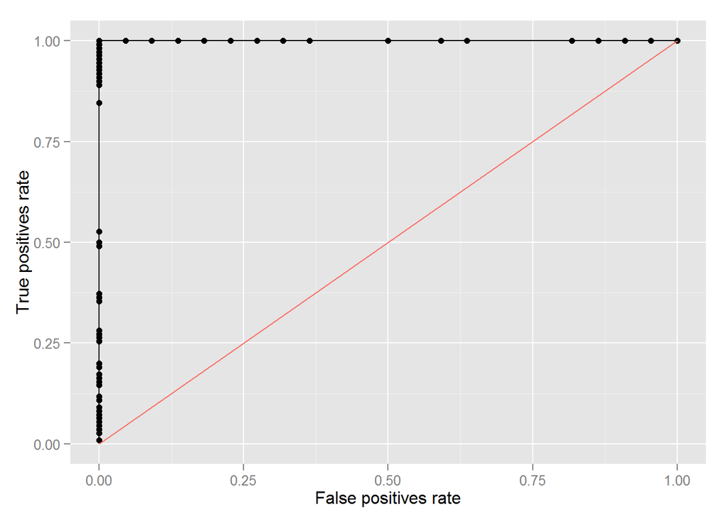

## ‘OFLO’ Details

### Elastic Net for Best Lambda

Lambda that minimizes CV error

```
## [1] 0.06
```

Corresponding CV error

```
## [1] 1.087
```

Number of nonzero coefficients (all non-zero)

```
## s47
##  48
```

Nonzero coefficients*:

| position | bp | coeficient |
| --- | --- | --- |
| 9 | 6620 | -0.0164 |
| 48 | 75937 | -0.0834 |
| 65 | 104853 | 0.0975 |
| 89 | 209944 | 0.2671 |
| 92 | 285751 | 0.3840 |
| 106 | 335845 | 0.0539 |
| 130 | 338618 | 0.0213 |
| 180 | 673241 | 0.4888 |
| 184 | 761158 | 0.1268 |
| 187 | 781690 | -0.1304 |
| 198 | 854607 | -0.1299 |
| 209 | 890552 | 0.2371 |
| 226 | 1020196 | 0.0926 |
| 240 | 1096402 | 0.1698 |
| 253 | 1191468 | -0.7338 |
| 278 | 1276890 | -0.1515 |
| 305 | 1473252 | -0.8469 |
| 312 | 1519836 | -0.0924 |
| 355 | 1637210 | -0.3381 |
| 369 | 1779376 | 0.0836 |
| 391 | 1907303 | 1.4530 |
| 412 | 2045317 | 0.0898 |
| 428 | 2155175 | 0.2501 |
| 439 | 2165510 | 0.1910 |
| 461 | 2264790 | -0.3253 |
| 498 | 2536839 | -0.6895 |
| 499 | 2598410 | 0.1616 |
| 504 | 2626610 | 0.4890 |
| 539 | 2973473 | 0.2892 |
| 540 | 2982608 | -1.3434 |
| 579 | 3481957 | 0.0213 |
| 593 | 3710567 | 0.2409 |
| 601 | 3730787 | 0.2732 |
| 602 | 3730813 | -0.0513 |
| 608 | 3732795 | 0.1180 |
| 637 | 3802338 | 1.2403 |
| 655 | 3883805 | 0.3113 |
| 671 | 3895261 | -0.7827 |
| 677 | 3927717 | -0.5806 |
| 678 | 3927718 | -0.1816 |
| 679 | 3927722 | -0.0106 |
| 691 | 3936269 | 0.2203 |
| 702 | 3936517 | -0.2060 |
| 715 | 3946974 | 0.4437 |
| 724 | 3948233 | -0.0359 |
| 729 | 4053229 | -0.5971 |
| 736 | 4121290 | 0.4040 |
| 749 | 4248181 | -0.0980 |

### Charts

Nonzero coefficients (LASSO):

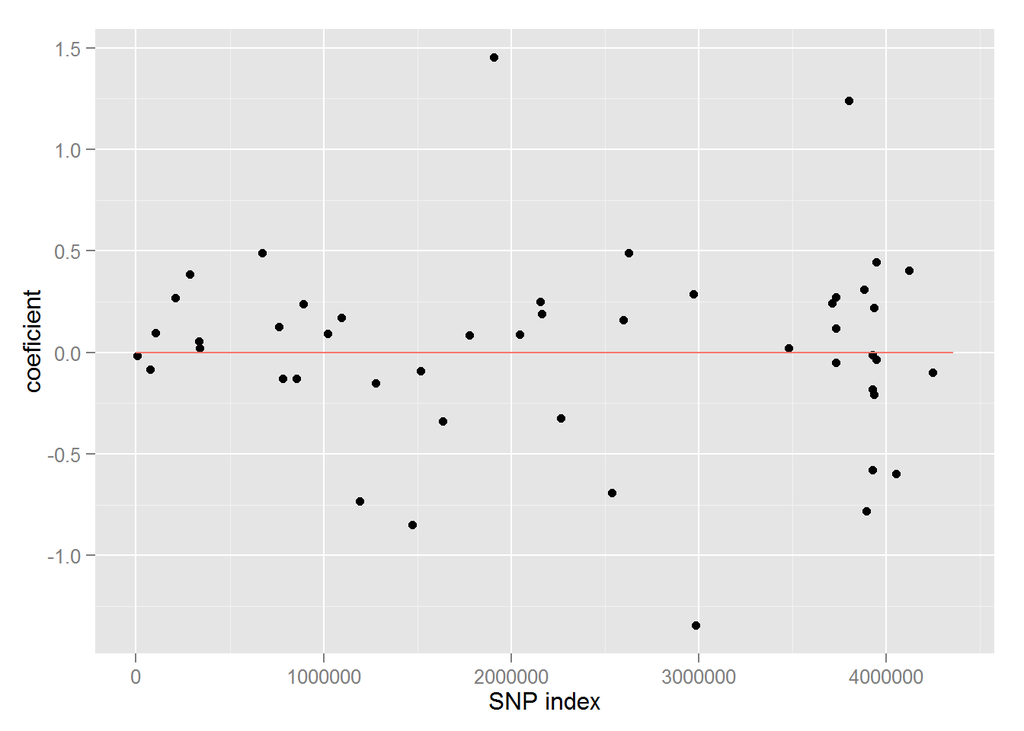

ROC curve for full model

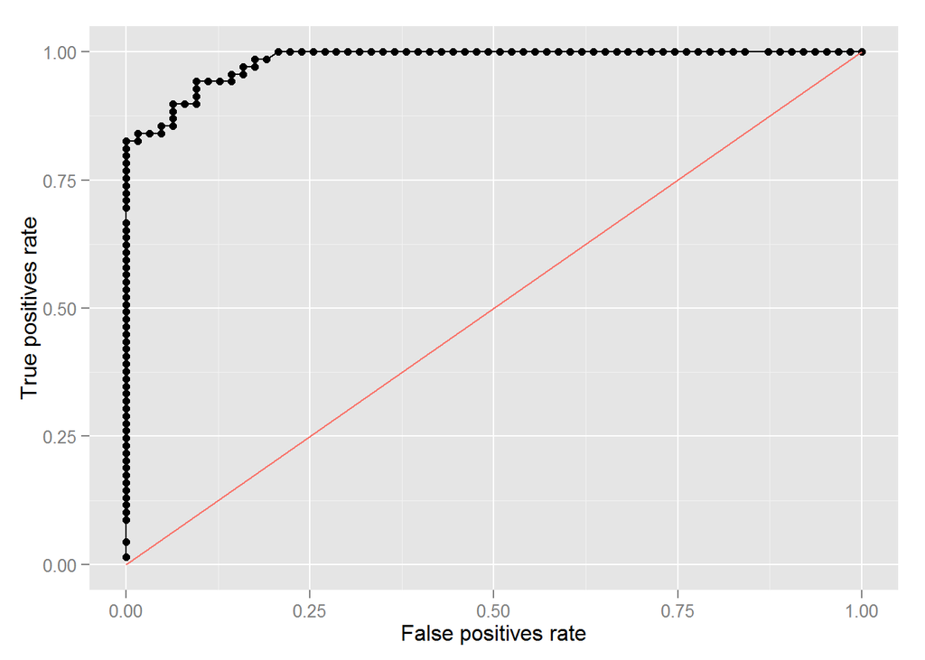

ROC curve for reduced model

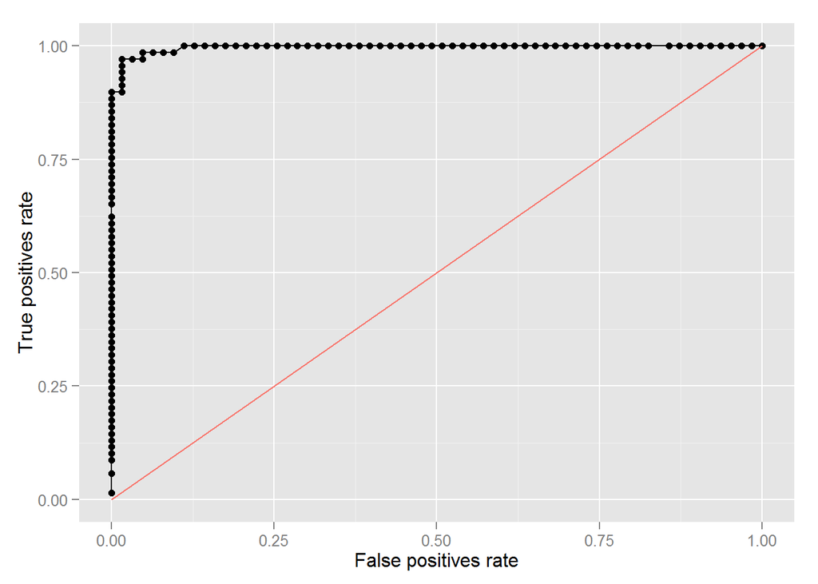

# Dataset: ‘dataset_2’ LASSO summary

## Full model prediction accuracy

| drug | 1 | 0 | 1/1 | 1/0 | 0/1 | 0/0 | precission | recall | f1 | accuracy |
| --- | --- | --- | --- | --- | --- | --- | --- | --- | --- | --- |
| OFLO | 10 | 38 | 0.2083 | 0 | 0 | 0.7917 | 1 | 1 | 1 | 1 |

## Reduced model prediction accuracy

| drug | 1 | 0 | 1/1 | 1/0 | 0/1 | 0/0 | precission | recall | f1 | accuracy |
| --- | --- | --- | --- | --- | --- | --- | --- | --- | --- | --- |
| OFLO | 10 | 38 | 0.2083 | 0 | 0 | 0.7917 | 1 | 1 | 1 | 1 |

## ‘OFLO’ Details

### Elastic Net for Best Lambda

Lambda that minimizes CV error

```
## [1] 0.02
```

Corresponding CV error

```
## [1] 0.5961
```

Number of nonzero coefficients (all non-zero)

```
## s49
##  18
```

Nonzero coefficients*:

| position | bp | coeficient |
| --- | --- | --- |
| 8 | 4086 | -0.8606 |
| 28 | 26959 | -0.1160 |
| 74 | 204977 | -0.0527 |
| 75 | 209944 | 0.8889 |
| 83 | 333615 | -0.1760 |
| 85 | 333624 | -0.2821 |
| 102 | 338322 | 2.7768 |
| 132 | 487328 | -2.4586 |
| 139 | 781690 | -0.9832 |
| 180 | 1276890 | -1.2809 |
| 195 | 1468465 | -0.4716 |
| 200 | 1519836 | -0.5127 |
| 224 | 1637210 | -0.3863 |
| 242 | 1982083 | -3.7150 |
| 269 | 2220520 | -1.3248 |
| 327 | 3382124 | -1.7162 |
| 385 | 3927774 | -1.3104 |
| 407 | 3943928 | -0.8279 |

### Charts

Nonzero coefficients (LASSO):

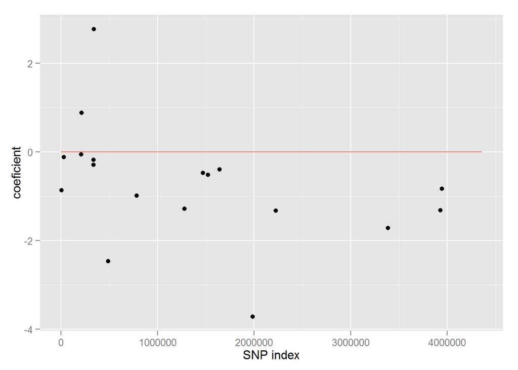

ROC curve for full model

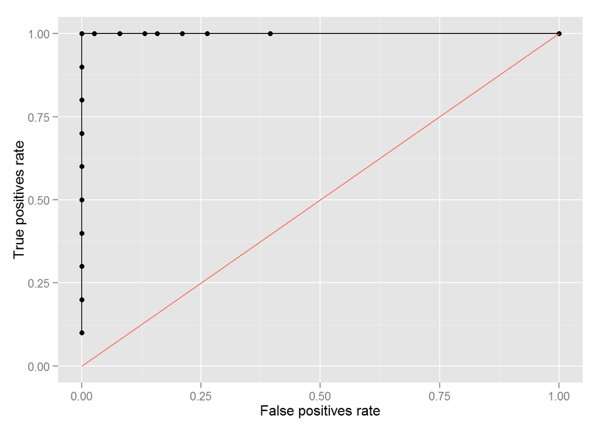

ROC curve for reduced model

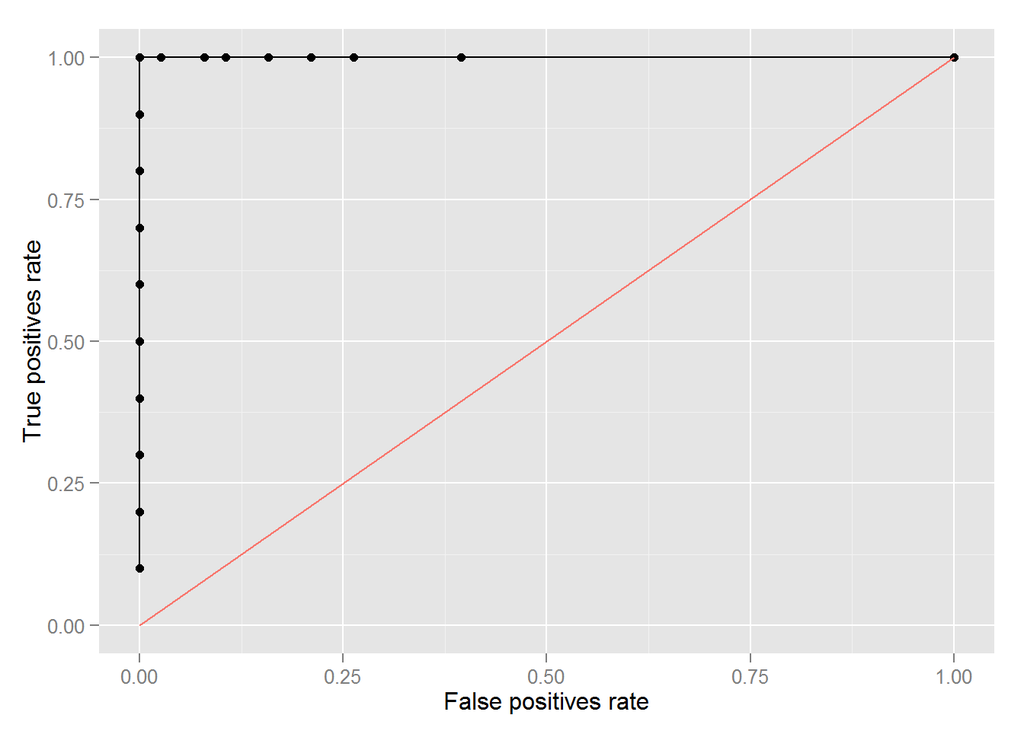

# Dataset: ‘dataset_3’ LASSO summary

## Full model prediction accuracy

| drug | 1 | 0 | 1/1 | 1/0 | 0/1 | 0/0 | precission | recall | f1 | accuracy |
| --- | --- | --- | --- | --- | --- | --- | --- | --- | --- | --- |
| AMIK | 8 | 46 | 0.1481 | 0 | 0 | 0.8519 | 1 | 1 | 1 | 1 |
| CAPR | 10 | 40 | 0.2000 | 0 | 0 | 0.8000 | 1 | 1 | 1 | 1 |

## Reduced model prediction accuracy

| drug | 1 | 0 | 1/1 | 1/0 | 0/1 | 0/0 | precission | recall | f1 | accuracy |
| --- | --- | --- | --- | --- | --- | --- | --- | --- | --- | --- |
| AMIK | 8 | 46 | 0.1481 | 0 | 0 | 0.8519 | 1 | 1 | 1 | 1 |
| CAPR | 10 | 40 | 0.2000 | 0 | 0 | 0.8000 | 1 | 1 | 1 | 1 |

## ‘AMIK’ Details

### Elastic Net for Best Lambda

Lambda that minimizes CV error

```
## [1] 0.02
```

Corresponding CV error

```
## [1] 0.3934
```

Number of nonzero coefficients (all non-zero)

```
## s49
##  10
```

Nonzero coefficients*:

| position | bp | coeficient |
| --- | --- | --- |
| 11 | 6579 | -6.4829 |
| 87 | 333624 | -0.7804 |
| 88 | 333632 | -0.1701 |
| 164 | 1001128 | -0.0160 |
| 178 | 1104278 | -3.4485 |
| 213 | 1473252 | -3.9834 |
| 290 | 2196889 | -0.5873 |
| 293 | 2220520 | -0.4943 |
| 346 | 3382124 | -1.1604 |
| 405 | 3927774 | -0.7742 |

### Charts

Nonzero coefficients (LASSO):

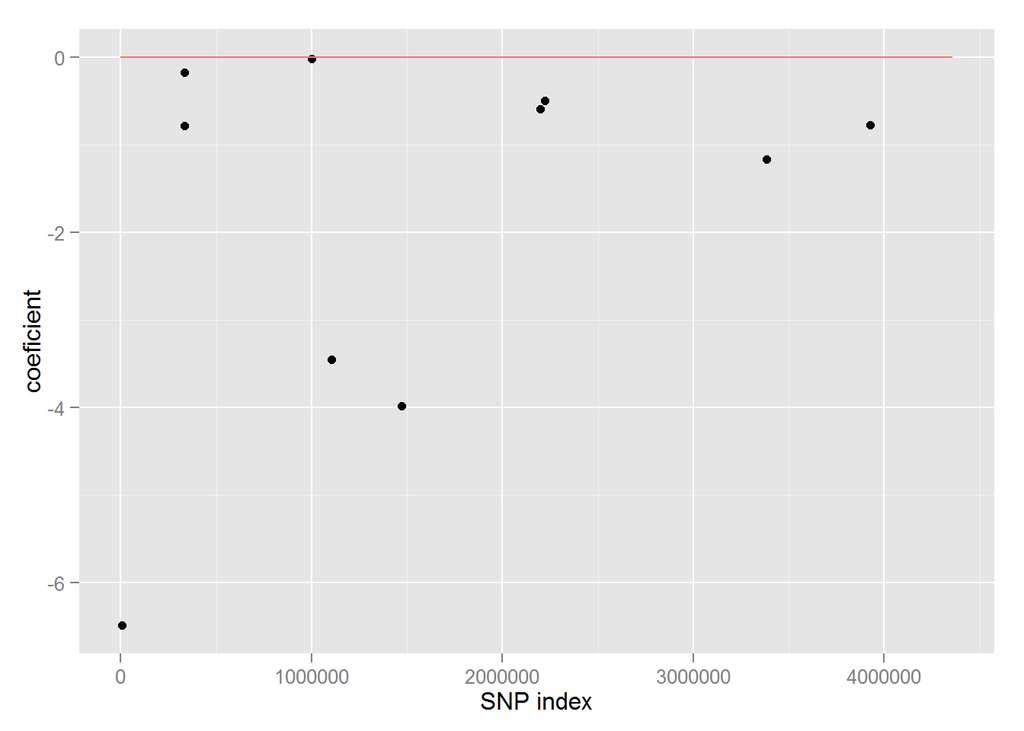

ROC curve for full model

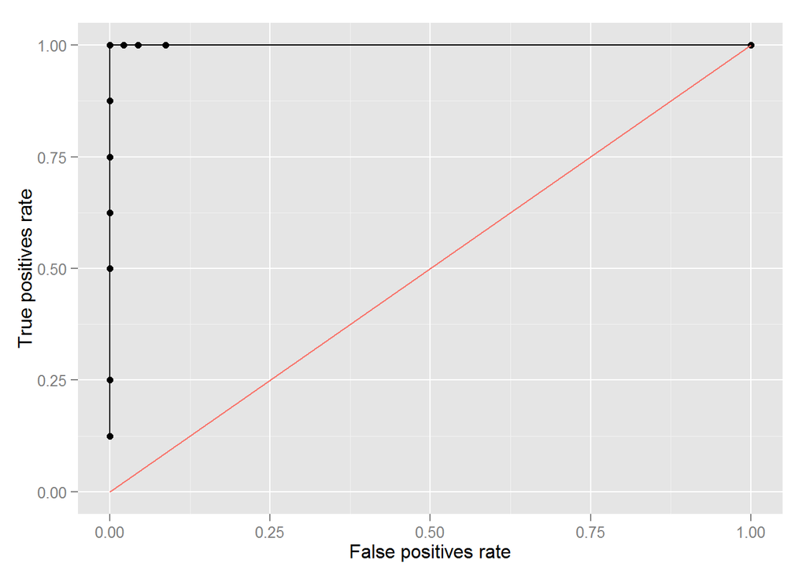

ROC curve for reduced model

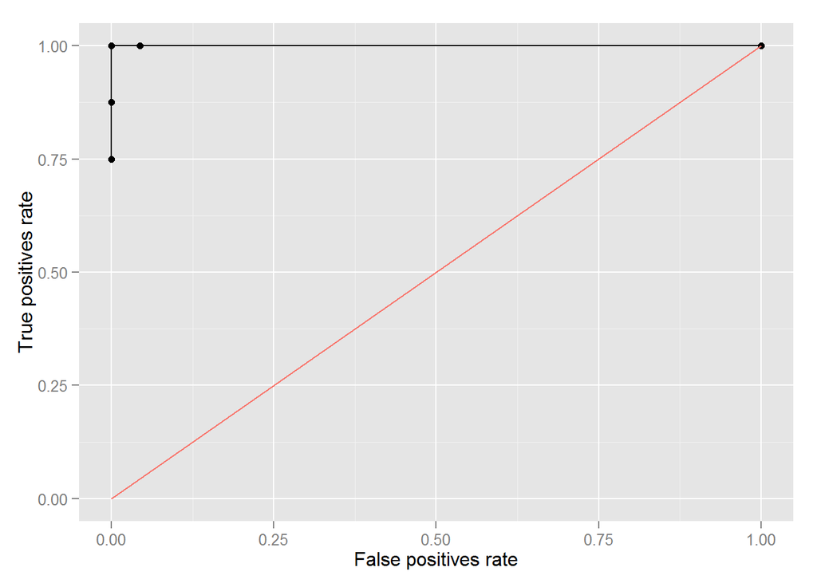

## ‘CAPR’ Details

### Elastic Net for Best Lambda

Lambda that minimizes CV error

```
## [1] 0.08
```

Corresponding CV error

```
## [1] 0.6896
```

Number of nonzero coefficients (all non-zero)

```
## s46
##  12
```

Nonzero coefficients*:

| position | bp | coeficient |
| --- | --- | --- |
| 11 | 6579 | -2.9581 |
| 74 | 125401 | -0.0400 |
| 78 | 202369 | -3.4104 |
| 87 | 333624 | -0.7187 |
| 88 | 333632 | -0.1843 |
| 164 | 1001128 | -0.3173 |
| 178 | 1104278 | -0.0628 |
| 289 | 2196889 | -0.5168 |
| 292 | 2220520 | -0.5541 |
| 307 | 2439527 | -0.0258 |
| 345 | 3382124 | -1.2005 |
| 404 | 3927774 | -1.2374 |

### Charts

Nonzero coefficients (LASSO):

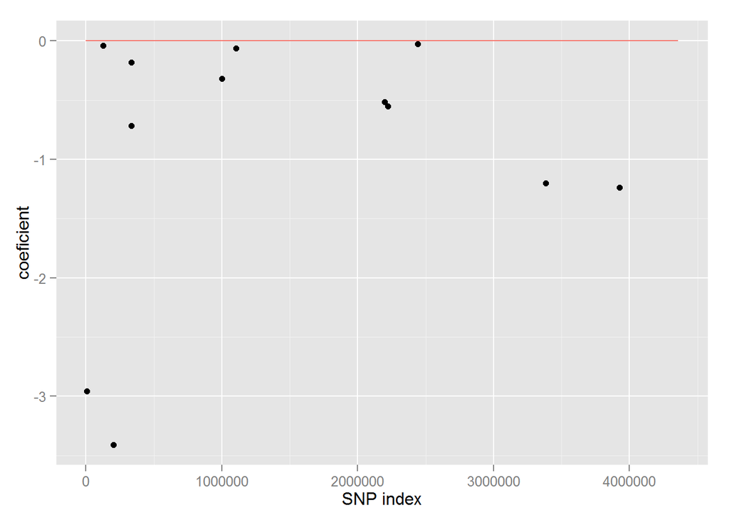

ROC curve for full model

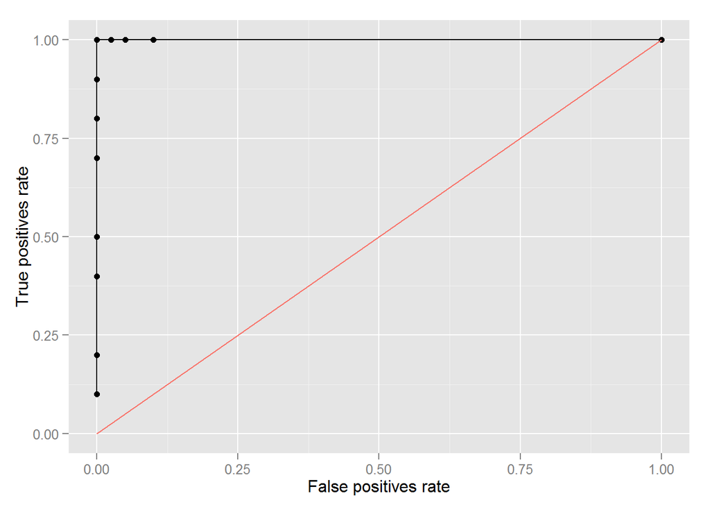

ROC curve for reduced model

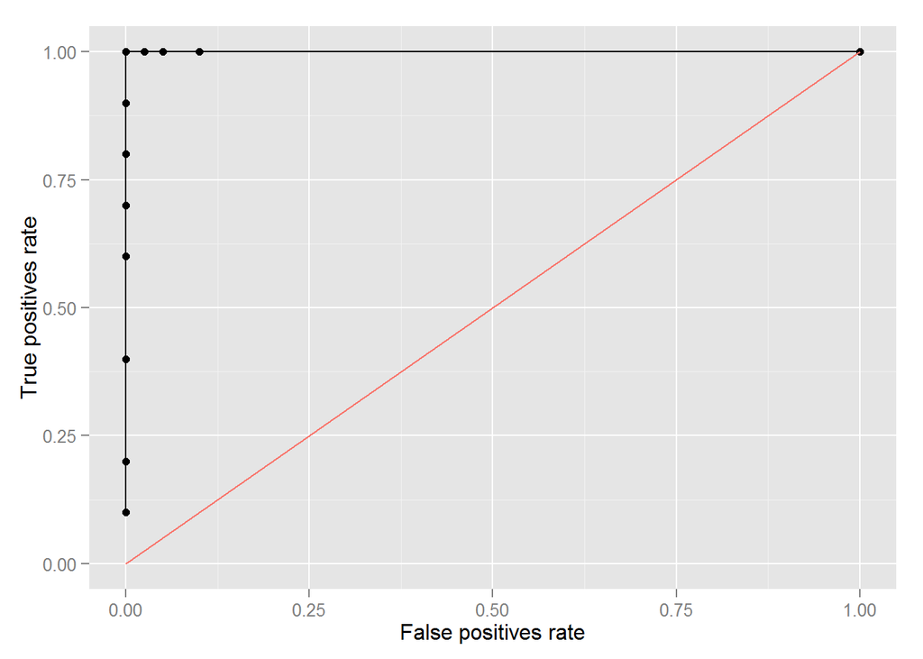

# Dataset: ‘dataset_4’ LASSO summary

## Full model prediction accuracy

| drug | 1 | 0 | 1/1 | 1/0 | 0/1 | 0/0 | precission | recall | f1 | accuracy |
| --- | --- | --- | --- | --- | --- | --- | --- | --- | --- | --- |
| OFLO | 10 | 38 | 0.2083 | 0 | 0 | 0.7917 | 1 | 1 | 1 | 1 |

## Reduced model prediction accuracy

| drug | 1 | 0 | 1/1 | 1/0 | 0/1 | 0/0 | precission | recall | f1 | accuracy |
| --- | --- | --- | --- | --- | --- | --- | --- | --- | --- | --- |
| OFLO | 10 | 38 | 0.2083 | 0 | 0 | 0.7917 | 1 | 1 | 1 | 1 |

## ‘OFLO’ Details

### Elastic Net for Best Lambda

Lambda that minimizes CV error

```
## [1] 0.02
```

Corresponding CV error

```
## [1] 0.5961
```

Number of nonzero coefficients (all non-zero)

```
## s49
##  18
```

Nonzero coefficients*:

| position | bp | coeficient |
| --- | --- | --- |
| 8 | 4086 | -0.8606 |
| 28 | 26959 | -0.1160 |
| 74 | 204977 | -0.0527 |
| 75 | 209944 | 0.8889 |
| 83 | 333615 | -0.1760 |
| 85 | 333624 | -0.2821 |
| 102 | 338322 | 2.7768 |
| 132 | 487328 | -2.4586 |
| 139 | 781690 | -0.9832 |
| 180 | 1276890 | -1.2809 |
| 195 | 1468465 | -0.4716 |
| 200 | 1519836 | -0.5127 |
| 224 | 1637210 | -0.3863 |
| 242 | 1982083 | -3.7150 |
| 269 | 2220520 | -1.3248 |
| 327 | 3382124 | -1.7162 |
| 385 | 3927774 | -1.3104 |
| 407 | 3943928 | -0.8279 |

### Charts

Nonzero coefficients (LASSO):

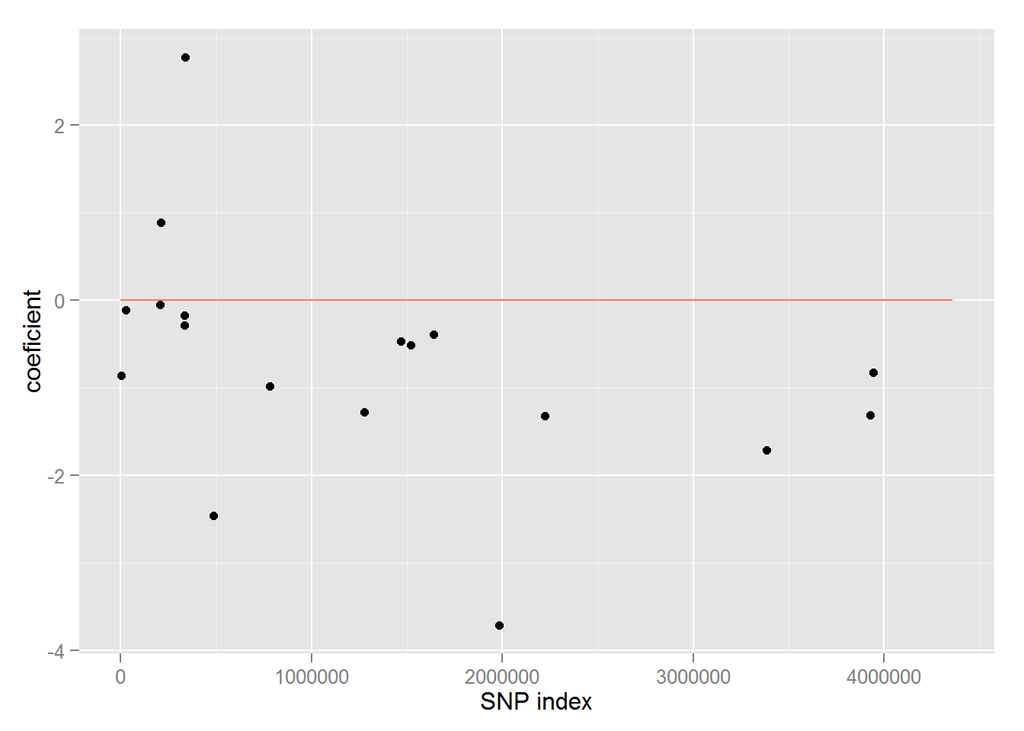

ROC curve for full model

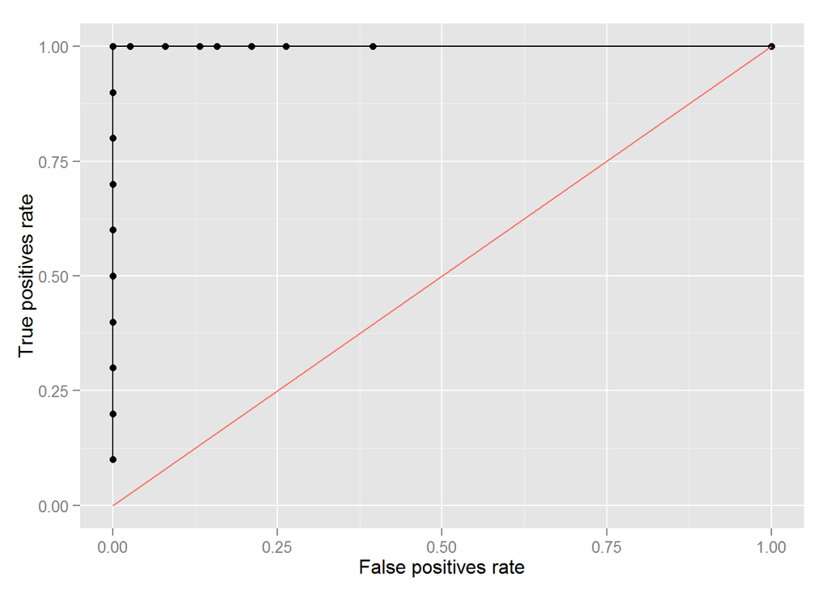

ROC curve for reduced model

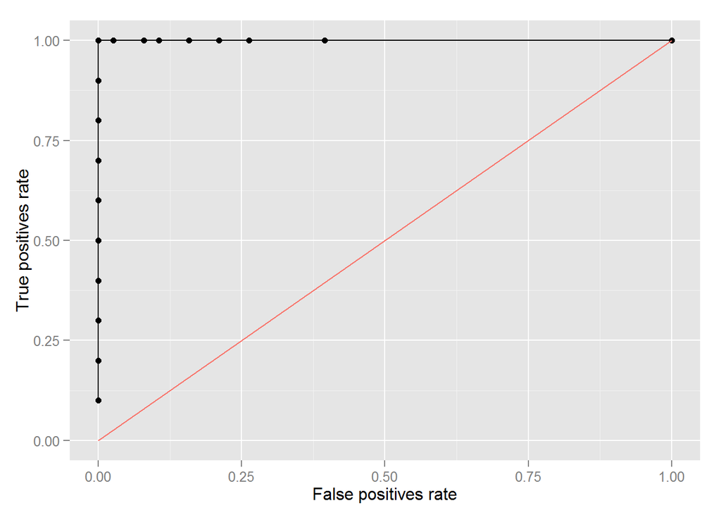